# Fixed Effects Models

Group 8: Chen Xie, Yanlin Yang, Nam H Le

December 07, 2018

### Introduction

#### General Description

In statistics, a model that has fixed parameters or non-random quantities is called **fixed effects model**.

In general, based on some observed factors, data can be divided into groups. The group means could be assumed as constant or non-constant across groups. And in a fixed effects model, just as its name implies, each group mean is a specifically fixed quantity.

Furthermore, the assumption of fixed effect is that the group-specific effects are correlated with the independent variables.

Thus, in the fixed effect models, if the heterogeneity is fixed over time, this unobserved heterogeneity can be controlled. This heterogeneity is removable from the data by differencing, for instance, any time invariant components of the model can be taken away by taking a first difference.

#### Panel Data

In this tutorial, we will focus on fixed effects model with panel data.

Panel data (also known as longitudinal or cross-sectional time-series data) is a dataset, where the behavior of entities is observed across time. The possible entities could be states, companies, individuals, countries, etc.

In panel data, fixed effects stand for the subject-specific means. In panel data analysis, fixed effects estimator is referred to an estimator for the coefficients in the regression model including those fixed effects, in other words, one time-invariant intercept for each subject.

#### Classical Representation

The linear unobserved effects model for $N$ observations and $T$ time periods:

$$y_{it}=X_{it}\beta+\alpha_i+\mu_{it} ,\ for \ t=1,..,T \ and \ i=1,...,N$$

Where:

$y_{it}$ is the dependent variable observed for individual i at time t.

$X_{it}$ is the time-variant $T\times k$ (the number of independent variables) regression matrix.

$\beta$ is the $k\times 1$ matrix of parameters.

$\alpha _{i}$ is the unobserved time-invariant individual effect.

$\mu_{it}$ is the error term.

### Overview

In this tutorial, we will use R, SAS and STATA to fit fixed effect models and compared them with ordinary linear regression models.

The dataset **Cigar** is a built-in dataset in the **plm** package in R. It is clean enough for us to do the data analysis directly.

### Example Dataset: Cigar

The dataset **Cigar** is a panel of 46 observations from 1963 to 1992 of cigarette consuming.

The total number of observations is 1380.

The panel data **Cigar** looks like this （first 10 observations）:

| state | year | price | pop | pop16 | cpi | ndi | sales | pimin |
| --- | --- | --- | --- | --- | --- | --- | --- | --- |
| 1 | 63 | 28.6 | 3383 | 2236.5 | 30.6 | 1558.305 | 93.9 | 26.1 |
| 1 | 64 | 29.8 | 3431 | 2276.7 | 31.0 | 1684.073 | 95.4 | 27.5 |
| 1 | 65 | 29.8 | 3486 | 2327.5 | 31.5 | 1809.842 | 98.5 | 28.9 |
| 1 | 66 | 31.5 | 3524 | 2369.7 | 32.4 | 1915.160 | 96.4 | 29.5 |
| 1 | 67 | 31.6 | 3533 | 2393.7 | 33.4 | 2023.546 | 95.5 | 29.6 |
| 1 | 68 | 35.6 | 3522 | 2405.2 | 34.8 | 2202.486 | 88.4 | 32.0 |
| 1 | 69 | 36.6 | 3531 | 2411.9 | 36.7 | 2377.335 | 90.1 | 32.8 |
| 1 | 70 | 39.6 | 3444 | 2394.6 | 38.8 | 2591.039 | 89.8 | 34.3 |
| 1 | 71 | 42.7 | 3481 | 2443.5 | 40.5 | 2785.316 | 95.4 | 35.8 |
| 1 | 72 | 42.3 | 3511 | 2484.7 | 41.8 | 3034.808 | 101.1 | 37.4 |

#### Variables:

The varaibles used for regression and fixed effect model:

Dependent variable:

```
sales: cigarette sales in packs per capita.
```

Independent variables (may be transformed):

```
pop: population.

pop16: population above the age of 16.

price: price per pack of cigarettes.

cpi: consumer price index (1983=100).

ndi: per capita disposable income.
```

Fixed effects variables:

[output not shown]

#### Why Fixed Effects Models

Heterogeneity in fixed effects models means different means among categories such as *states* and *years*. When the data can be grouped by such categories, and there are also some evidences indicating heterogeneity, the OLS is not sufficient to control the effects of these unobservable factors. However, fixed effects models can control and estimate these effects. Moreover, if these unobservable factors are time-invariant, then omitted variable bias can be eliminated by fixed effects regression.

##### Heterogeneity across year

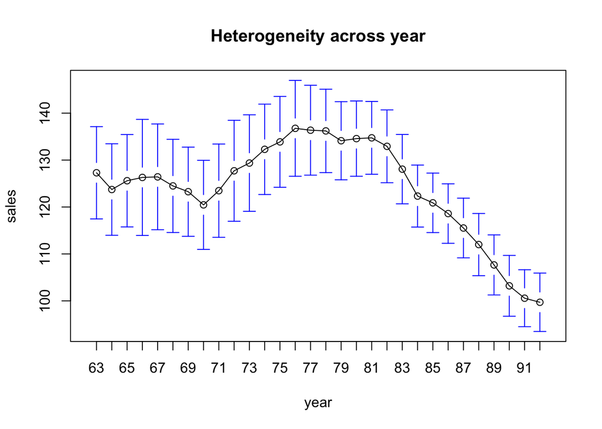

The above graph shows that the means of *sales* for distinct *year* are different.

##### Heterogeneity across state

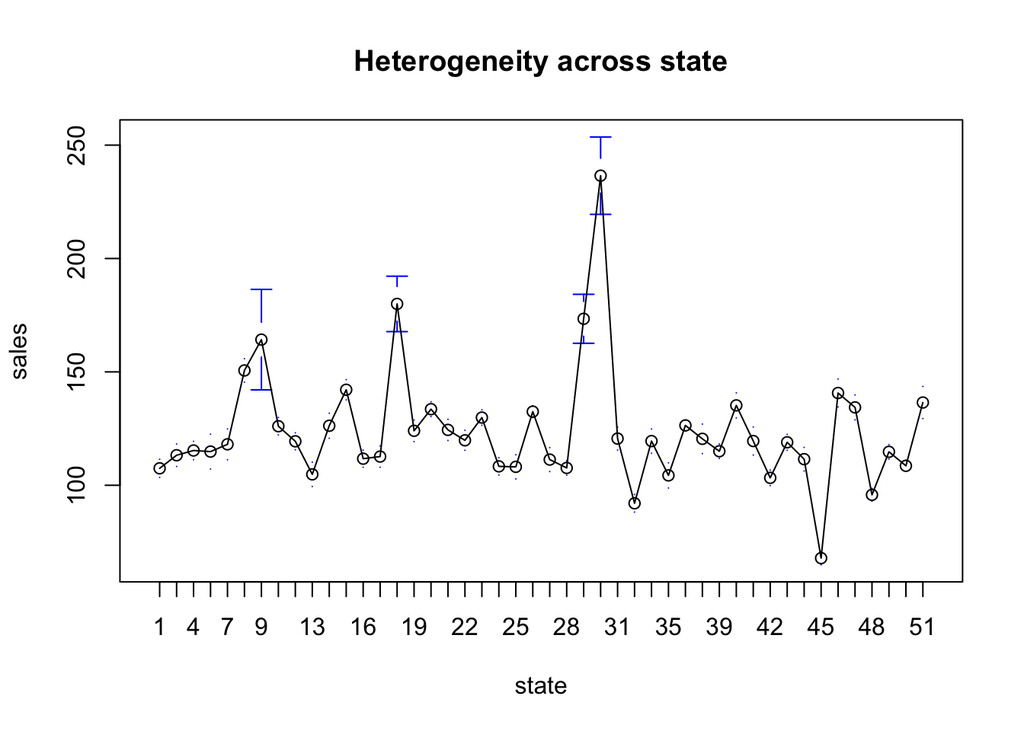

We can also observe heterogeneity across *state* from the above graph. Therefore, fixed effects model is an ideal choice.

### Tutorial in R

#### Data Manipulation

Import the data:

```r
# data: the dataset 'Cigar' is available inside the 'plm' package
library(plm)
data(Cigar)
```

Transform the variables:

```r
# Adjust the price, and disposable income with cpi to
# get the dollar value in 1983
attach(Cigar)
Cigar$price_adj=(price/cpi)*100
Cigar$income_adj = (ndi/cpi)*100
```

#### OLS regression

Fit an OLS regression model with *sale* as the response and *price_adj*, *pop*, *pop16* and *income_adj* as predictors:

```r
# Run ordinary linear regression without fixed effect
ols = lm(sales ~ price_adj + pop + pop16 + income_adj, data = Cigar)
summary(ols)
```

```
##
## Call:
## lm(formula = sales ~ price_adj + pop + pop16 + income_adj, data = Cigar)
##
## Residuals:
##     Min      1Q  Median      3Q     Max
## -73.905 -12.834  -2.860   7.873 162.438
##
## Coefficients:
##               Estimate Std. Error t value Pr(>|t|)
## (Intercept)  1.897e+02  5.254e+00  36.111  < 2e-16 ***
## price_adj   -1.247e+00  5.378e-02 -23.185  < 2e-16 ***
## pop          1.040e-02  2.447e-03   4.248 2.30e-05 ***
## pop16       -1.495e-02  3.276e-03  -4.564 5.46e-06 ***
## income_adj   5.278e-03  4.379e-04  12.054  < 2e-16 ***
## ---
## Signif. codes:  0 '***' 0.001 '**' 0.01 '*' 0.05 '.' 0.1 ' ' 1
##
## Residual standard error: 26 on 1375 degrees of freedom
## Multiple R-squared:  0.2981, Adjusted R-squared:  0.2961
## F-statistic:   146 on 4 and 1375 DF,  p-value: < 2.2e-16
```

From the summary above, we see that the coefficient of *price_adj*, *pop*, *pop16* and *income_adj* are -1.247e+00, 1.040e-02, -1.495e-02, 5.278e-03 respectively.

#### Fixed Effects Models

We fit a fixed effects model with *sale* as the response, *price_adj*, *pop*, *pop16*, *income_adj* as independent variables, and *state* and *year* as fixed effects variables.

There are three ways to do with R, using the regular funtions **lm**, the **felm** in the **lfe** package, or **plm** in the **plm** package. In fact, they produce the same results.

The **lm** generates dummies variables for *state* and *year* and then run linear regression. However, the **felm** and **plm** will absorb individual fixed effects estimates.

If we just want to control for fix effect and only care about coefficients of interests, either **felm** and **plm** is a good choice. But if we want to know the effect of some specific groups, **lm** is preferred.

##### Basic R:

In fact, the summary of **lm** will show individual fixed effects estimates for every year and every state. But for convenience, we only show the estimated coefficients of independent variables and first five estimated effects for years.

```r
# Fixed effects using Least squares dummy variable model
ols_fixed = lm(sales ~ price_adj + pop + pop16 + income_adj +factor(year) + factor(state), data = Cigar)
summary(ols_fixed)$coefficients[1:10,]
```

```
##                     Estimate   Std. Error     t value      Pr(>|t|)
## (Intercept)    254.871577992 8.0047498533  31.8400428 5.576540e-165
## price_adj       -1.474957838 0.0712776661 -20.6931276  1.840630e-82
## pop              0.001908401 0.0018072543   1.0559672  2.911793e-01
## pop16           -0.002180001 0.0021201973  -1.0282068  3.040437e-01
## income_adj      -0.002320871 0.0007200866  -3.2230442  1.299815e-03
## factor(year)64  -0.675374024 2.5764491002  -0.2621337  7.932599e-01
## factor(year)65   1.071170096 2.6189757232   0.4090034  6.826045e-01
## factor(year)66   5.615730191 2.6730827193   2.1008441  3.584666e-02
## factor(year)67   5.353523777 2.7114760535   1.9743946  4.854810e-02
## factor(year)68   7.346161519 2.7803640858   2.6421581  8.336775e-03
```

##### Package **lfe**:

```r
# Use lfe package, treat *state* and *year* as fixed effects variables, and fit a model
library(lfe)
felm_fixed = felm(sales ~ price_adj + pop + pop16 + income_adj |factor(year) + factor(state), data = Cigar)
summary(felm_fixed)
```

```
##
## Call:
##    felm(formula = sales ~ price_adj + pop + pop16 + income_adj |      factor(year) + factor(state), data = Cigar)
##
## Residuals:
##     Min      1Q  Median      3Q     Max
## -63.049  -5.140  -0.117   5.525 108.515
##
## Coefficients:
##              Estimate Std. Error t value Pr(>|t|)
## price_adj  -1.4749578  0.0712777 -20.693   <2e-16 ***
## pop         0.0019084  0.0018073   1.056   0.2912
## pop16      -0.0021800  0.0021202  -1.028   0.3040
## income_adj -0.0023209  0.0007201  -3.223   0.0013 **
## ---
## Signif. codes:  0 '***' 0.001 '**' 0.01 '*' 0.05 '.' 0.1 ' ' 1
##
## Residual standard error: 12.29 on 1301 degrees of freedom
## Multiple R-squared(full model): 0.8515   Adjusted R-squared: 0.8426
## Multiple R-squared(proj model): 0.2545   Adjusted R-squared: 0.2098
## F-statistic(full model):95.67 on 78 and 1301 DF, p-value: < 2.2e-16
## F-statistic(proj model):   111 on 4 and 1301 DF, p-value: < 2.2e-16
```

##### Package **plm**:

```r
# Use plm package, treat *state* and *year* as fixed effects variables, and fit a model
library(plm)
plm_md = plm(sales ~ price_adj + pop + pop16 + income_adj, data = Cigar,
          index = c("year", "state"), model = "within", effect = "twoways")
summary(plm_md)
```

```
## Twoways effects Within Model
##
## Call:
## plm(formula = sales ~ price_adj + pop + pop16 + income_adj, data = Cigar,
##     effect = "twoways", model = "within", index = c("year", "state"))
##
## Balanced Panel: n = 30, T = 46, N = 1380
##
## Residuals:
##      Min.   1st Qu.    Median   3rd Qu.      Max.
## -63.04920  -5.13997  -0.11695   5.52514 108.51496
##
## Coefficients:
##               Estimate  Std. Error  t-value Pr(>|t|)
## price_adj  -1.47495784  0.07127767 -20.6931   <2e-16 ***
## pop         0.00190840  0.00180725   1.0560   0.2912
## pop16      -0.00218000  0.00212020  -1.0282   0.3040
## income_adj -0.00232087  0.00072009  -3.2230   0.0013 **
## ---
## Signif. codes:  0 '***' 0.001 '**' 0.01 '*' 0.05 '.' 0.1 ' ' 1
##
## Total Sum of Squares:    263760
## Residual Sum of Squares: 196630
## R-Squared:      0.25451
## Adj. R-Squared: 0.20982
## F-statistic: 111.043 on 4 and 1301 DF, p-value: < 2.22e-16
```

### Tutorial in SAS

#### Data Manipulation

Import the data:

```r
/* read the data file  */
proc import datafile=".\Cigar.csv"
out=mydata dbms=csv replace;
getnames=yes;
run;
```

Transform the variables:

```r
/*change the price, and income with cpi to get the dollar value in 1983 */
data Cigar; set mydata;
price_adj = (price/cpi)*100;
income_adj = (ndi/cpi)*100;
run;
```

#### OLS regression

```r
proc reg data=Cigar;
 model sales = price_adj pop pop16 income_adj;
 run;
quit;
```

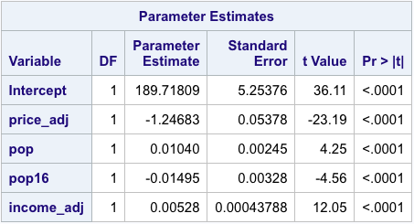

#### Fixed Effects Models

In SAS, the **glm** is to fit with fixed effects models. In **glm**, we can either use **class** or **absorb** to determine the fixed effects variables.

If we want to see the fixed effects estimates for every *state* and every *year*, **class** will be the first choice. The **class** will automatically generate a set of dummy variables for each level of the variable *state* and *year*.

It we only want to know the estimates of our interested independent variables, we can use **absorb** instead of **class**. But it can only absorb one variable at a time. And to use the **absorb**, we need to suppress the intercept to avoid a dummy variable trap.

We only show the estimated coefficients of independent variables and first five estimated effects for years.

##### Use **class**:

For convenience, we only show the estimated coefficients of independent variables and first five estimated effects for years. But in fact, in SAS, individual fixed effects estimate for every *state* and every *year* will be displayed.

```r
/* Fixed effects by class, generating a set of dummy variables */
/* for each level of the variable state and year               */
proc glm data=Cigar;
 class year state;
 model sales = price_adj pop pop16 income_adj year state/ solution; run;
quit;
```

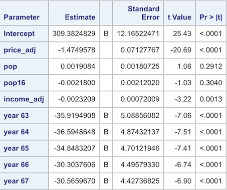

##### Use **absorb**:

In SAS, as we absorb the variable *state*, only individual fixed effects estimate for every *year* will be displayed. And we only show the first five estimated effects for years.

```r
/* Absorbing the variable *state* and generating dummies of years */
proc glm data=Cigar;
 absorb state;
 class year;
 model sales = price_adj pop pop16 income_adj year/ solution noint; run;
quit;
```

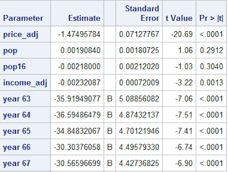

##### Summary

The estimates of the independent variables *price_adj*, *pop*, *pop16*, *income_adj* are the same as the R.

We will find the estimates for years are different from those in R. This is because that R will automatically treat one level of the factors as the reference levels, in this case, the reference levels are *year 63* or *state 1*, and incorporating them into the estimated intercept. While SAS has no such process.

Though some differences are watched, by simple calculations the estimates are the same.

### Tutorial in STATA

#### Data Manipulation

Import the data:

```r
import delimited Cigar.csv, clear
```

Transform the variables:

```r
## change the price, and income with cpi to get the dollar value in 1983
g price_adj = (price/cpi)*100
g income_adj = (ndi/cpi)*100
```

#### OLS regression

```r
reg sales price_adj pop pop16 income_adj
```

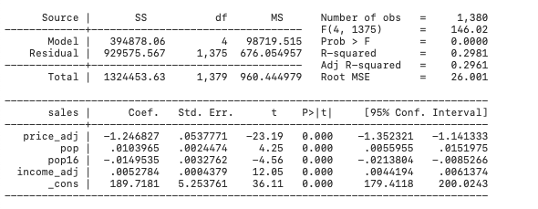

#### Fixed Effects Models

There are three ways to do with STATA, using the commands **areg**, **xtreg**, or **reghdfe**. In fact, they produce the same results.

The **areg** and **xtreg** cannot absorb more than one fix effect, but we can still put factor variable i.var in. Sometimes, they are computationally inefficient since they actually calculate and report coefficients for those dummy variables. However, in some cases they could be helpful if we want to see the effect of one specific group.

If we just want to control for fix effect and only care about other coefficients of interests, **reghdfe** is the best option.

##### Command **areg**:

```r
## Absorbing the variable state and generating dummies of years
areg sales price_adj pop pop16 income_adj i.year, absorb(state)
```

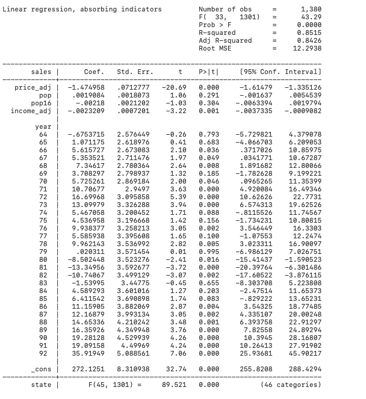

##### Command **xtreg**:

```r
## Absorbing the variable state and generating dummies of years
xtset state year
xtreg sales price_adj pop pop16 income_adj i.year, fe
```

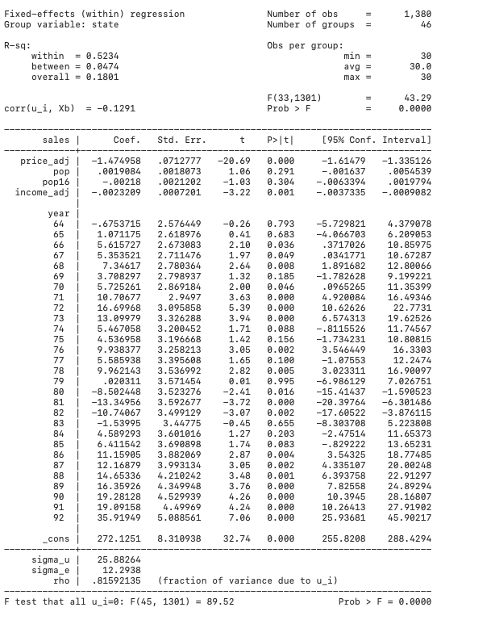

##### Command **reghdfe**:

install packages:

```r
## install reghdfe packages, and also ftools
ssc install reghdfe
ssc install ftools
```

regression:

```r
## Absorbing the variables state and year using reghdfe
reghdfe sales price_adj pop pop16 income_adj, absorb(state year)
```

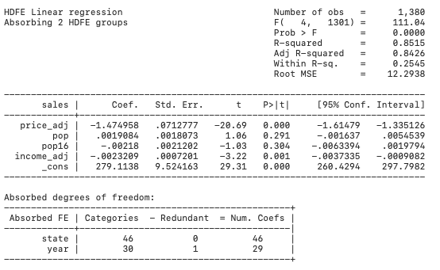

##### Summary

The estimates of the independent variables *price_adj*, *pop*, *pop16*, *income_adj* are the same as the R and the SAS.

Same as R, STATA will also take *year 63* and *state 1* by default as reference levels. So, the estimated effects for years equal to those of R. As STATA absorbs variables, the estimated intercepts are different. But in fact, the models are the same.

### Discussion and Summary

#### Compare Fixed Effects Model to OLS

The results of the OLS and the fixed effects model are extremely different. To be more specific, with fixed effect the negative effect of *price* on *sales* is stronger in magnitude than the OLS, and the coefficient on *income* flips sign.

#### Importance of Fixed Effects Model

If we fit OLS instead of fixed effects, we will underestimate the effects of *price* on *sales* of cigarette, and even have wrong conclusion for the influence of *income* on *sales*. So, it highlights the importance of controlling for fix effect.

#### Absorption or Not

When computing fixed effects models estimates, we should choose to absorb them or not. It depends on what our aim is. Absorption is computationally fast, and looks concisely, however, individual fixed effects estimates will not be showed. In order to get every individual fixed effects estimates, the preferred method is “no absorption”, which will automatically generate a set of dummy variables for each level of the fixed effects variable.

### References

**Wikipedia:** [Fixed effects model](https://en.wikipedia.org/wiki/Fixed_effects_model)

**Dataset:** [Cigar](http://www-eio.upc.edu/~pau/cms/rdata/csv/Ecdat/Cigar.csv)

**R Package:** [plm](https://cran.r-project.org/web/packages/plm/)

**R Package:** [lfe](https://cran.r-project.org/web/packages/lfe/lfe.pdf)

**STATA Package:** [reghdfe](http://scorreia.com/demo/reghdfe.html)

**Notes:** [Panel Data using R](https://www.princeton.edu/~otorres/Panel101R.pdf)

**Notes:** [Fixed Effects in SAS](https://kelley.iu.edu/nstoffma/fe.html)